# Assignment 3

Leona Ma

11/5/2021

# Part1 data scraping

## Step1 How many papers were you able to find

```r
# Downloading the website
website <- xml2::read_html("https://pubmed.ncbi.nlm.nih.gov/?term=sars-cov-2%20trial%20vaccine")

# Finding the counts
counts <- xml2::xml_find_first(website, "//*[@id='search-results']/div[2]/div[1]/div[1]/span")

# Turning it into text
# or xml2::xml_text(counts)
counts <- as.character(counts)

# Extracting the data using regex
stringr::str_extract(counts, "[0-9,]+")
```

```
## [1] "2,336"
```

I found 2336 papers.

## Step2 retrieve the details of the paper

```r
query_ids <- GET(
  url = "https://eutils.ncbi.nlm.nih.gov/",
  path = "entrez/eutils/esearch.fcgi",
  query = list(db = "pubmed",
               term = "sars-cov-2 trial vaccine",
               retmax = 250)
)
ids <- httr::content(query_ids)

# Turn the result into a character vector
ids <- as.character(ids)

# Find all the ids
ids <- stringr::str_extract_all(ids, "<Id>[[:digit:]]+</Id>")[[1]]

# Remove all the leading and trailing <Id> </Id>. Make use of "|"
ids <- stringr::str_remove_all(ids, "<Id>|</Id>")
head(ids)
```

```
## [1] "34735795" "34735426" "34735018" "34729549" "34726743" "34715931"
```

## Step3 download each papers’ details using the query parameter rettype = abstract

```r
publications <- GET(
  url   = "https://eutils.ncbi.nlm.nih.gov/",
  path = "entrez/eutils/efetch.fcgi",
  query = list(
    db = "pubmed",
    id = I(paste(ids, collapse=",")),
    retmax = 250,
    rettype = "abstract"
    )
)

# Turning the output into character vector
publications <- httr::content(publications)
publications_txt <- as.character(publications)
```

## Step4 Create a dataset

```r
pub_char_list <- xml2::xml_children(publications)
pub_char_list <- sapply(pub_char_list, as.character)

#Title of the paper
title <- str_extract(pub_char_list, "<ArticleTitle>[[:print:][:space:]]+</ArticleTitle>")
title <- str_remove_all(title, "</?[[:alnum:]- =\"]+>")

#Name of the journal where it was published
journalnames <- str_extract(pub_char_list, "<Title>[[:print:][:space:]]+</Title>")
journalnames <- str_remove_all(journalnames, "</?[[:alnum:]- =\"]+>")

#Publication date
date <- str_extract(pub_char_list, "<PubDate>[[:print:][:space:]]+</PubDate>")
date <- str_remove_all(date, "</?[[:alnum:]]+>")
date <- str_replace_all(date, "\\s+", " ")

# abstract
abstracts <- str_extract(pub_char_list, "<Abstract>[[:print:][:space:]]+</Abstract>")
abstracts <- str_remove_all(abstracts, "</?[[:alnum:]- =\"]+>") # '</?[[:alnum:]- ="]+>'
abstracts <- str_replace_all(abstracts, "[[:space:]]+", " ")

database <- data.frame(
  PubMedId = ids[1:250],
  Title    = title,
  Journal  = journalnames,
  Date     = date,
  Abstract = abstracts
)

knitr::kable(database[1:10,], caption = "articles about sars-cov-2 trial vaccine")
```

articles about sars-cov-2 trial vaccine

| PubMedId | Title | Journal | Date | Abstract |
| --- | --- | --- | --- | --- |
| 34735795 | Immunogenicity of standard and extended dosing intervals of BNT162b2 mRNA vaccine. | Cell | 2021 Oct 16 | Extension of the interval between vaccine doses for the BNT162b2 mRNA vaccine was introduced in the United Kingdom to accelerate population coverage with a single dose. At this time, trial data were l… |
| 34735426 | Effectiveness of 2-Dose Vaccination with mRNA COVID-19 Vaccines Against COVID-19-Associated Hospitalizations Among Immunocompromised Adults - Nine States, January-September 2021. | MMWR. Morbidity and mortality weekly report | 2021 Nov 05 | Immunocompromised persons, defined as those with suppressed humoral or cellular immunity resulting from health conditions or medications, account for approximately 3% of the U.S. adult population (1).… |
| 34735018 | COVID-19 Therapeutics and Vaccines: A Race to save Lives. | Toxicological sciences : an official journal of the Society of Toxicology | 2021 Nov 04 | COVID-19 (Coronavirus Disease 2019), the disease caused by SARS-CoV-2 (Severe Acute Respiratory Syndrome Coronavirus-2) is an ongoing global public health emergency. As understanding of the health eff… |
| 34729549 | Adverse events of active and placebo groups in SARS-CoV-2 vaccine randomized trials: A systematic review. | The Lancet regional health. Europe | 2021 Oct 28 | For safety assessment in clinical trials, adverse events (AEs) are reported for the drug under evaluation and compared with AEs in the placebo group. Little is known about the nature of the AEs associ… |
| 34726743 | Analysis of the Effectiveness of the Ad26.COV2.S Adenoviral Vector Vaccine for Preventing COVID-19. | JAMA network open | 2021 11 01 | Continuous assessment of the effectiveness and safety of the US Food and Drug Administration-authorized SARS-CoV-2 vaccines is critical to amplify transparency, build public trust, and ultimately impr… |
| 34715931 | Lessons from Israel’s COVID-19 Green Pass program. | Israel journal of health policy research | 2021 10 29 | As of the beginning of March 2021, Israeli law requires the presentation of a Green Pass as a precondition for entering certain businesses and public spheres. Entitlement for a Green Pass is granted t… |
| 34713912 | Vaccine development and technology for SARS-CoV-2: current insights. | Journal of medical virology | 2021 Oct 29 | SARS-CoV-2 is associated to a severe respiratory disease in China, that rapidly spread across continents. Since the beginning of the pandemic, available data suggested the asymptomatic transmission an… |
| 34711598 | BCG vaccination to reduce the impact of COVID-19 in healthcare workers: Protocol for a randomised controlled trial (BRACE trial). | BMJ open | 2021 10 28 | BCG vaccination modulates immune responses to unrelated pathogens. This off-target effect could reduce the impact of emerging pathogens. As a readily available, inexpensive intervention that has a wel… |
| 34704204 | COVID-19 Testing and Vaccine Acceptability Among Homeless-Experienced Adults: Qualitative Data from Two Samples. | Journal of general internal medicine | 2021 Oct 26 | Homeless-experienced populations are at increased risk of exposure to SARS-CoV-2 due to their living environments and face an increased risk of severe COVID-19 disease due to underlying health conditi… |
| 34703690 | A Rare Variant of Guillain-Barre Syndrome Following Ad26.COV2.S Vaccination. | Cureus | 2021 Sep | Efforts to combat the global pandemic caused by severe acute respiratory syndrome coronavirus 2 (SARS-CoV-2) range from adequate diagnostic testing and contract tracing to vaccination for the preventi… |

# Part2 Text mining

## Step1 Import data

```r
pubmed <- "pubmend.csv"
if (!file.exists(pubmed))
  download.file("https://raw.githubusercontent.com/USCbiostats/data-science-data/master/03_pubmed/pubmed.csv", destfile = pubmed)

pubmed <- read.csv(pubmed)
pubmed <- as_tibble(pubmed)
```

## Step2 Tokenize the abstracts and count the number of each token

```r
# Before removal of stop words
pubmed %>%
  unnest_tokens(token, abstract) %>%
  count(token, sort = TRUE)
```

```
## # A tibble: 20,567 x 2
##    token     n
##    <chr> <int>
##  1 the   28126
##  2 of    24760
##  3 and   19993
##  4 in    14653
##  5 to    10920
##  6 a      8245
##  7 with   8038
##  8 covid  7275
##  9 19     7080
## 10 is     5649
## # … with 20,557 more rows
```

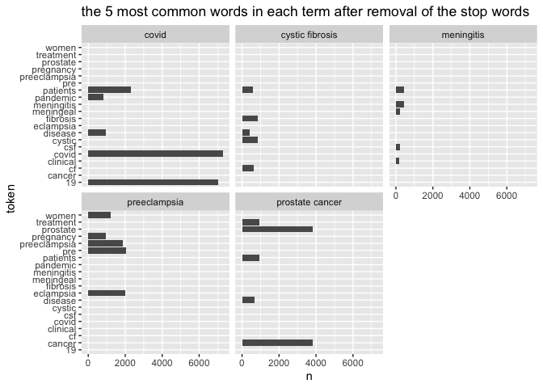

```r
# After removal of stop words
pubmed %>%
  unnest_tokens(token, abstract) %>%
  anti_join(stop_words, by = c("token" = "word")) %>%
  group_by(term) %>%
  count(token, sort = TRUE)%>%
  top_n(5,n)%>%
  ggplot(aes(x=token,y=n))+
  facet_wrap(~term) +
  geom_col()+
  coord_flip() +
  labs(title = "the 5 most common words in each term after removal of the stop words")
```

Before removal of the stop words, the words that appear most frequency are “the”, “of”, “and” and so on, which barely give us information about these abstracts. After removal of the stop words, we can see from the plot that the frequently appeared words are “covid”, “preeclampsia”, “prostate” and so on, which are much more clear and informative. But there is a problem that “covid” and “19” are split up, which is why we need to tokenize the abstracts into bigrams next step.

## Step3 Tokenize the abstracts into bigrams

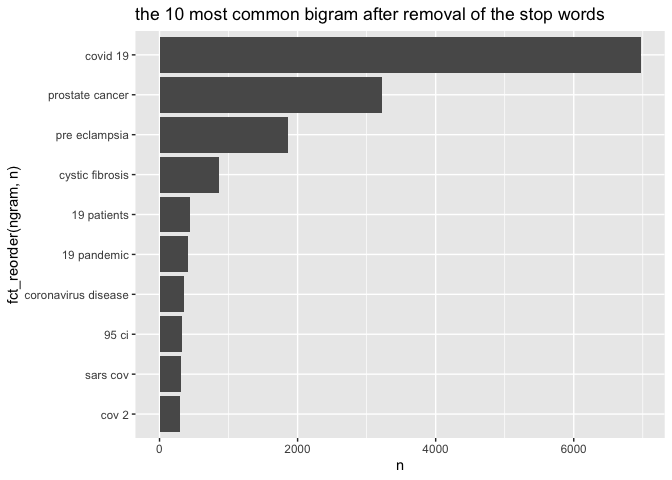

```r
bigrams <-pubmed %>%
  unnest_ngrams(ngram, abstract, n = 2) %>%
  separate(ngram, into = c("word1", "word2"), sep = " ") %>%
  select(word1, word2) %>%
  anti_join(stop_words, by = c("word1" = "word")) %>%
  anti_join(stop_words, by = c("word2" = "word")) %>%
  count(word1, word2, sort = TRUE) %>%
  top_n(10, n)
  unite(bigrams, "ngram", c("word1", "word2"), sep = " ") %>%
  ggplot(aes(x = n, y = fct_reorder(ngram, n))) +
  geom_col()+
  labs(title = "the 10 most common bigram after removal of the stop words")
```

We learned form step2 that excluding stop words can make our text mining get more information. Thus, I remove the stop words directly during this step.

## Step4 Calculate the TF-IDF value for each word-search term combination

```r
pubmed %>%
  unnest_tokens(token, abstract) %>%
  count(term, token, sort = TRUE) %>%
  bind_tf_idf(token, term, n) %>%
  group_by(term) %>%
  top_n(5, tf_idf) %>%
  arrange(desc(tf_idf), .by_group = TRUE) %>%
  select(term, token, n, tf_idf, tf, idf) %>%
  knitr::kable(caption="the 5 tokens from each search term with the highest TF-IDF value")
```

the 5 tokens from each search term with the highest TF-IDF value

| term | token | n | tf_idf | tf | idf |
| --- | --- | --- | --- | --- | --- |
| covid | covid | 7275 | 0.0597183 | 0.0371050 | 1.6094379 |
| covid | pandemic | 800 | 0.0065670 | 0.0040803 | 1.6094379 |
| covid | coronavirus | 647 | 0.0053110 | 0.0032999 | 1.6094379 |
| covid | sars | 372 | 0.0030536 | 0.0018973 | 1.6094379 |
| covid | cov | 334 | 0.0027417 | 0.0017035 | 1.6094379 |
| cystic fibrosis | cf | 625 | 0.0116541 | 0.0127188 | 0.9162907 |
| cystic fibrosis | fibrosis | 867 | 0.0090127 | 0.0176435 | 0.5108256 |
| cystic fibrosis | cystic | 862 | 0.0089608 | 0.0175417 | 0.5108256 |
| cystic fibrosis | cftr | 86 | 0.0028167 | 0.0017501 | 1.6094379 |
| cystic fibrosis | sweat | 83 | 0.0027184 | 0.0016891 | 1.6094379 |
| meningitis | meningitis | 429 | 0.0147974 | 0.0091942 | 1.6094379 |
| meningitis | meningeal | 219 | 0.0075539 | 0.0046935 | 1.6094379 |
| meningitis | pachymeningitis | 149 | 0.0051394 | 0.0031933 | 1.6094379 |
| meningitis | csf | 206 | 0.0040453 | 0.0044149 | 0.9162907 |
| meningitis | meninges | 106 | 0.0036562 | 0.0022718 | 1.6094379 |
| preeclampsia | eclampsia | 2005 | 0.0229802 | 0.0142784 | 1.6094379 |
| preeclampsia | preeclampsia | 1863 | 0.0213527 | 0.0132672 | 1.6094379 |
| preeclampsia | pregnancy | 969 | 0.0035250 | 0.0069006 | 0.5108256 |
| preeclampsia | maternal | 797 | 0.0028993 | 0.0056757 | 0.5108256 |
| preeclampsia | gestational | 191 | 0.0021891 | 0.0013602 | 1.6094379 |
| prostate cancer | prostate | 3832 | 0.0501967 | 0.0311890 | 1.6094379 |
| prostate cancer | androgen | 305 | 0.0039953 | 0.0024824 | 1.6094379 |
| prostate cancer | psa | 282 | 0.0036940 | 0.0022952 | 1.6094379 |
| prostate cancer | prostatectomy | 215 | 0.0028164 | 0.0017499 | 1.6094379 |
| prostate cancer | castration | 148 | 0.0019387 | 0.0012046 | 1.6094379 |

As we can see form the table, the 5 words with the highest TF-IDF value in each search term provide even more information compared to question1 (step2). In question1, we still got some words that are very common in medical field, like “woman”, “treatment”, “disease”, which actually still gave us limited information. In this question, the words with highest TF-IDF value are more informative.